# Projeto com Feedback 2

Marcos Rogel Pacheco dos Reis

15 de Novembro de 2019

# 1 Carregar Pacotes

```r
if (!require("pacman")) install.packages("pacman")
```

```r
pacman::p_load(knitr, tidyverse, highcharter, data.table, DT, skimr, gridExtra, corrplot, Matrix, xgboost, Metrics)
```

# 2 Carregar dados

```r
setwd("~/GitHub/DSA.Projetos-FCD-BigData.R.Azure-Projeto2")
source("src/utils.R")
input_df <- fread("train.csv",data.table = TRUE, blank.lines.skip = TRUE,
                  select = c("Semana",'Cliente_ID', 'Producto_ID', 'Agencia_ID', 'Ruta_SAK', 'Demanda_uni_equil','Canal_ID'),
                  colClasses = c(Semana = "factor",
                                 Agencia_ID = "factor",
                                 Canal_ID = "factor",
                                 Ruta_SAK = "factor",
                                 Cliente_ID = "factor",
                                 Producto_ID = "factor"))
```

# 3 Visualizar dados

```r
datatable(head(input_df, 100), class = 'table-bordered table-condensed')
```

|  | Semana | Cliente_ID | Producto_ID | Agencia_ID | Ruta_SAK | Demanda_uni_equil | Canal_ID |
| --- | --- | --- | --- | --- | --- | --- | --- |
| 1 | 3 | 15766 | 1212 | 1110 | 3301 | 3 | 7 |
| 2 | 3 | 15766 | 1216 | 1110 | 3301 | 4 | 7 |
| 3 | 3 | 15766 | 1238 | 1110 | 3301 | 4 | 7 |
| 4 | 3 | 15766 | 1240 | 1110 | 3301 | 4 | 7 |
| 5 | 3 | 15766 | 1242 | 1110 | 3301 | 3 | 7 |
| 6 | 3 | 15766 | 1250 | 1110 | 3301 | 5 | 7 |
| 7 | 3 | 15766 | 1309 | 1110 | 3301 | 3 | 7 |
| 8 | 3 | 15766 | 3894 | 1110 | 3301 | 6 | 7 |
| 9 | 3 | 15766 | 4085 | 1110 | 3301 | 4 | 7 |
| 10 | 3 | 15766 | 5310 | 1110 | 3301 | 6 | 7 |

[output cut: 90 more lines]

# 4 Exibir tipos de dados

```r
str(input_df)
```

```
## Classes 'data.table' and 'data.frame':   74180464 obs. of  7 variables:
##  $ Semana           : Factor w/ 7 levels "3","4","5","6",..: 1 1 1 1 1 1 1 1 1 1 ...
##  $ Cliente_ID       : Factor w/ 880604 levels "100000","1000001",..: 131385 131385 131385 131385 131385 131385 131385 131385 131385 131385 ...
##  $ Producto_ID      : Factor w/ 1799 levels "100","1039","106",..: 36 37 44 45 46 47 53 1153 1177 1711 ...
##  $ Agencia_ID       : Factor w/ 552 levels "1110","1111",..: 1 1 1 1 1 1 1 1 1 1 ...
##  $ Ruta_SAK         : Factor w/ 3603 levels "1","10","100",..: 1286 1286 1286 1286 1286 1286 1286 1286 1286 1286 ...
##  $ Demanda_uni_equil: int  3 4 4 4 3 5 3 6 4 6 ...
##  $ Canal_ID         : Factor w/ 9 levels "1","11","2","4",..: 7 7 7 7 7 7 7 7 7 7 ...
##  - attr(*, ".internal.selfref")=<externalptr>
```

# 5 Quantidade de valores distintos das variáveis categóricas

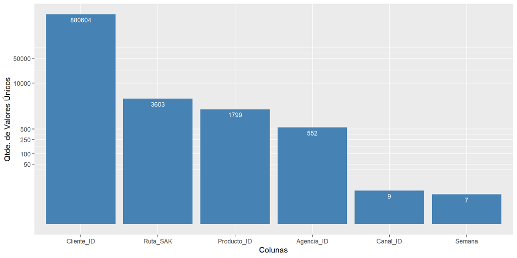

```r
cathegorical_vars <- c("Semana" ,"Agencia_ID" ,"Canal_ID" ,"Ruta_SAK" ,"Cliente_ID" ,"Producto_ID" )
input_df[, lapply(.SD, uniqueN), .SDcols = cathegorical_vars] %>%
  melt(variable.name = "columns", value.name = "values") %>%
  ggplot(aes(reorder(columns, -values), values)) +
  geom_bar(stat = "identity", fill = "steelblue") +
  scale_y_log10(breaks = c(50,100,250, 500, 10000, 50000)) +
  geom_text(aes(label = values), vjust = 1.6, color = "white", size=3) +
  theme_gray()+
  labs(x = "Colunas", y = "Qtde. de Valores Únicos")
```

# 6 Sumário dos dados do dataset

```r
skim(input_df)
```

|  | variable | type | stat | level | value | formatted |
| --- | --- | --- | --- | --- | --- | --- |
| 1 | Semana | factor | missing | .all | 0 | 0 |
| 2 | Semana | factor | complete | .all | 74180464 | 74180464 |
| 3 | Semana | factor | n | .all | 74180464 | 74180464 |
| 4 | Semana | factor | n_unique | .all | 7 | 7 |
| 5 | Semana | factor | top_counts | 3 | 11165207 | 3: 11165207 |
| 6 | Semana | factor | top_counts | 4 | 11009593 | 4: 11009593 |
| 7 | Semana | factor | top_counts | 5 | 10615397 | 5: 10615397 |
| 8 | Semana | factor | top_counts | 9 | 10408713 | 9: 10408713 |
| 9 | Semana | factor | top_counts | 8 | 10406868 | 8: 10406868 |
| 10 | Semana | factor | top_counts | 7 | 10382849 | 7: 10382849 |

[output cut: 9990 more lines]

# 7 Plot TOP 15 Ocorrências de variáveis categóricas

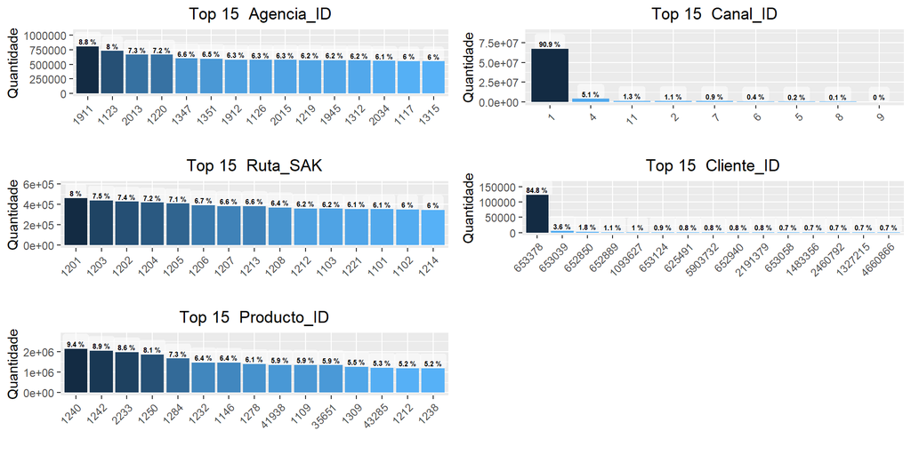

```r
plots <- lapply(setdiff(cathegorical_vars,'Semana'), plotTopVars,input_df,TRUE,15)

grid.arrange(grobs=plots,ncol = 2, nrow=3)
```

# 8 Análise por semana

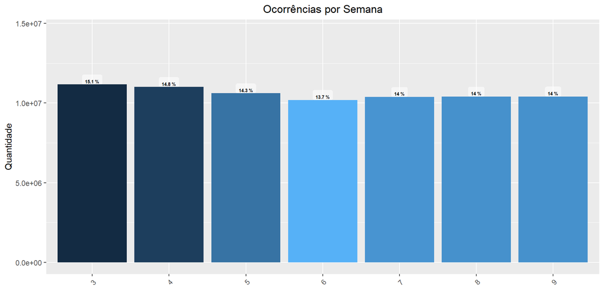

```r
plotTopVars('Semana',input_df,FALSE,15,"Ocorrências por Semana")
```

# 9 Correlação entre todas as variáveis

Optou-se por realizar uma amostragem dos dados pois processar a correlação no conjunto inteiro de dados fazia a máquina travar.

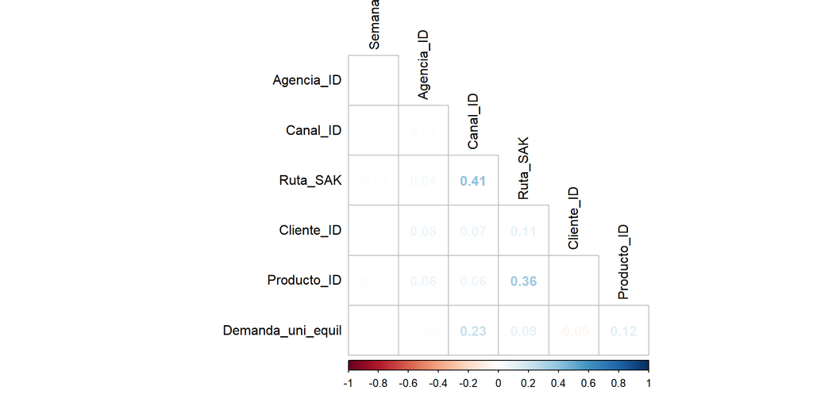

# 10 Definir dados de Treino e de Teste

Uma vez que não se possui acesso aos resultados das previsões do dataset “test.csv” fornecido , optou-se por utilizar apenas os dados do arquivo “train.csv” para a construção do modelo, fornecendo assim uma possibilidade de se avaliar a previsão fornecida pelo modelo resultante. Contudo prezou-se em manter a mesma estrutura e lógicas existentes nos datasets originais.

## 10.1 Visualizando dados do arquivo “test.csv”

Para reproduzir o comportamento do dataset de teste original é necessário, primeiramente, compreendê-lo e captar suas características de modo a reproduzi-las.

```r
original_train_df <- fread("test.csv",data.table = TRUE, blank.lines.skip = TRUE)
datatable(head(original_train_df, 100), class = 'table-bordered table-condensed')
```

|  | id | Semana | Agencia_ID | Canal_ID | Ruta_SAK | Cliente_ID | Producto_ID |
| --- | --- | --- | --- | --- | --- | --- | --- |
| 1 | 0 | 11 | 4037 | 1 | 2209 | 4639078 | 35305 |
| 2 | 1 | 11 | 2237 | 1 | 1226 | 4705135 | 1238 |
| 3 | 2 | 10 | 2045 | 1 | 2831 | 4549769 | 32940 |
| 4 | 3 | 11 | 1227 | 1 | 4448 | 4717855 | 43066 |
| 5 | 4 | 11 | 1219 | 1 | 1130 | 966351 | 1277 |
| 6 | 5 | 11 | 1146 | 4 | 6601 | 1741414 | 972 |
| 7 | 6 | 11 | 2057 | 1 | 4507 | 4659766 | 1232 |
| 8 | 7 | 10 | 1612 | 1 | 2837 | 4414012 | 35305 |
| 9 | 8 | 10 | 1349 | 1 | 1223 | 397854 | 1240 |
| 10 | 9 | 11 | 1461 | 1 | 1203 | 1646915 | 43203 |

[output cut: 90 more lines]

## 10.2 Quantidade de valores distintos da variável Semana

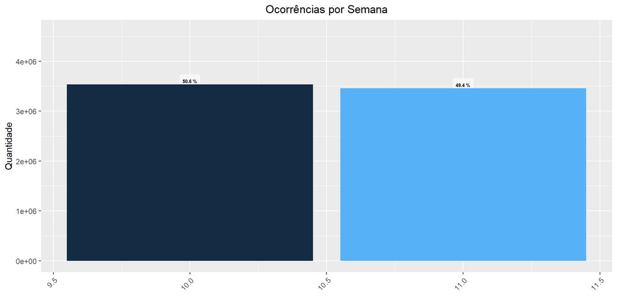

```r
plotTopVars('Semana',original_train_df,FALSE,15,"Ocorrências por Semana")
```

## 10.3 Criando dados de treino e de teste a partir do dataset de entrada (dataset de treino original)

O dataset de teste original possui apenas as colunas “id,”Semana",‘Cliente_ID’, ‘Producto_ID’, ‘Agencia_ID’, ‘Ruta_SAK’ e ‘Canal_ID’, com isto para simular a previsão utilizando apenas o dataset de treino original, selecionou-se apenas as colunas em comum entre treino e teste originais.

```r
train <- input_df[Semana <=7]
test<-input_df[Semana > 7,]
rm(input_df)

invisible(gc())
```

# 11 Feature Engeneering

## 11.1 Quantidade de produto entregue nas semanas anteriores

Adicinou-se uma feature que indica a quantidade de produto que foi entregue na(s) semana(s) anterior(es), optou-se por adicionar o histórico de entregas de 3 semanas uma vez que este foi o limite suportado pelo hardware da máquina que processou o modelo.

As Semanas existentes no dataset de treino vão de 3 a 7, sendo a sétima a ultima semana. Cria-se 3 features, cada uma indicando a quantidade de vendas nas 3 semanas semanas anteriores a sétima.

```r
train <- train[Semana > 3,]

invisible(gc())

data1<-train[,.(Semana=Semana+1,Cliente_ID,Producto_ID,Demanda_uni_equil)]
train <- merge(train,data1[Semana>6,.(Demanda_uni_equil_lag_1=mean(Demanda_uni_equil)), by=.(Semana,Cliente_ID,Producto_ID)],all.x=T, by=c("Semana","Cliente_ID","Producto_ID"))


test <- merge(test,data1[Semana>7,.(Demanda_uni_equil_lag_1=mean(Demanda_uni_equil)), by=.(Semana,Cliente_ID,Producto_ID)],all.x=T, by=c("Semana","Cliente_ID","Producto_ID"))

data1<-train[,.(Semana=Semana+2,Cliente_ID,Producto_ID,Demanda_uni_equil)]
train <- merge(train,data1[Semana>6,.(Demanda_uni_equil_lag_2=mean(Demanda_uni_equil)), by=.(Semana,Cliente_ID,Producto_ID)],all.x=T, by=c("Semana","Cliente_ID","Producto_ID"))

test <- merge(test,data1[Semana>7,.(Demanda_uni_equil_lag_2=mean(Demanda_uni_equil)), by=.(Semana,Cliente_ID,Producto_ID)],all.x=T, by=c("Semana","Cliente_ID","Producto_ID"))

data1<-train[,.(Semana=Semana+3,Cliente_ID,Producto_ID,Demanda_uni_equil)]
train <- merge(train,data1[Semana>6,.(Demanda_uni_equil_lag_3=mean(Demanda_uni_equil)), by=.(Semana,Cliente_ID,Producto_ID)],all.x=T, by=c("Semana","Cliente_ID","Producto_ID"))

test <- merge(test,data1[Semana>7,.(Demanda_uni_equil_lag_3=mean(Demanda_uni_equil)), by=.(Semana,Cliente_ID,Producto_ID)],all.x=T, by=c("Semana","Cliente_ID","Producto_ID"))

train <- train[Semana > 6]
head(train)

rm(data1)
invisible(gc())
```

### 11.1.1 Dados de treino

```r
datatable(head(train, 100), class = 'table-bordered table-condensed')
```

|  | Semana | Cliente_ID | Producto_ID | Agencia_ID | Canal_ID | Ruta_SAK | Demanda_uni_equil | Demanda_uni_equil_lag_1 | Demanda_uni_equil_lag_2 | Demanda_uni_equil_lag_3 |
| --- | --- | --- | --- | --- | --- | --- | --- | --- | --- | --- |
| 1 | 7 | 26 | 1182 | 2061 | 2 | 7212 | 0 |  |  |  |
| 2 | 7 | 26 | 4767 | 2061 | 2 | 7212 | 42 |  |  |  |
| 3 | 7 | 26 | 30314 | 2655 | 2 | 4189 | 48 |  |  |  |
| 4 | 7 | 26 | 31393 | 2061 | 2 | 7212 | 18 | 15 | 15 | 16 |
| 5 | 7 | 26 | 33246 | 2655 | 2 | 4189 | 30 | 10 | 10 | 30 |
| 6 | 7 | 26 | 34204 | 2061 | 2 | 7212 | 36 | 34 | 44 | 30 |
| 7 | 7 | 26 | 34206 | 2061 | 2 | 7212 | 96 | 69 | 42 | 81 |
| 8 | 7 | 26 | 34210 | 2061 | 2 | 7212 | 30 | 32 | 43 | 42 |
| 9 | 7 | 26 | 34211 | 2061 | 2 | 7212 | 53 | 23 | 31 | 37 |
| 10 | 7 | 26 | 34258 | 2061 | 2 | 7212 | 12 |  |  | 32 |

[output cut: 90 more lines]

### 11.1.2 Dados de teste

```r
datatable(head(test, 100), class = 'table-bordered table-condensed')
```

|  | Semana | Cliente_ID | Producto_ID | Agencia_ID | Canal_ID | Ruta_SAK | Demanda_uni_equil | Demanda_uni_equil_lag_1 | Demanda_uni_equil_lag_2 | Demanda_uni_equil_lag_3 |
| --- | --- | --- | --- | --- | --- | --- | --- | --- | --- | --- |
| 1 | 8 | 26 | 1182 | 2061 | 2 | 7212 | 0 | 0 |  |  |
| 2 | 8 | 26 | 4767 | 2061 | 2 | 7212 | 42 | 42 |  |  |
| 3 | 8 | 26 | 31393 | 2061 | 2 | 7212 | 22 | 18 | 15 | 15 |
| 4 | 8 | 26 | 34204 | 2061 | 2 | 7212 | 45 | 36 | 34 | 44 |
| 5 | 8 | 26 | 34206 | 2061 | 2 | 7212 | 89 | 96 | 69 | 42 |
| 6 | 8 | 26 | 34210 | 2061 | 2 | 7212 | 39 | 30 | 32 | 43 |
| 7 | 8 | 26 | 34211 | 2061 | 2 | 7212 | 34 | 53 | 23 | 31 |
| 8 | 8 | 26 | 34258 | 2061 | 2 | 7212 | 0 | 12 |  |  |
| 9 | 8 | 26 | 34264 | 2061 | 2 | 7212 | 20 | 7 | 14 | 10 |
| 10 | 8 | 26 | 34785 | 2061 | 2 | 7212 | 12 | 27 | 16 |  |

[output cut: 90 more lines]

## 11.2 Contagens das ocorrências de cada valor das variáveis categóricas

Efetua-se primeiramente uma contagem agrupada por semana e logo após obtêmm-se uma média geral das contagens de cada variável categórica no decorrer de todas as semanas.

### 11.2.1 Dados de treino

```r
datatable(head(train, 100), class = 'table-bordered table-condensed')
```

|  | Semana | Cliente_ID | Producto_ID | Agencia_ID | Canal_ID | Ruta_SAK | Demanda_uni_equil | Demanda_uni_equil_lag_1 | Demanda_uni_equil_lag_2 | Demanda_uni_equil_lag_3 | avgCount_Agencia_ID | avgCount_Canal_ID | avgCount_Ruta_SAK | avgCount_Cliente_ID | avgCount_Producto_ID |
| --- | --- | --- | --- | --- | --- | --- | --- | --- | --- | --- | --- | --- | --- | --- | --- |
| 1 | 7 | 26 | 1182 | 2061 | 2 | 7212 | 0 |  |  |  | 2489 | 120668 | 138 | 33 | 90986 |
| 2 | 7 | 26 | 4767 | 2061 | 2 | 7212 | 42 |  |  |  | 2489 | 120668 | 138 | 33 | 23921 |
| 3 | 7 | 26 | 30314 | 2655 | 2 | 4189 | 48 |  |  |  | 682 | 120668 | 3 | 33 | 1445 |
| 4 | 7 | 26 | 31393 | 2061 | 2 | 7212 | 18 | 15 | 15 | 16 | 2489 | 120668 | 138 | 33 | 3499 |
| 5 | 7 | 26 | 33246 | 2655 | 2 | 4189 | 30 | 10 | 10 | 30 | 682 | 120668 | 3 | 33 | 124 |
| 6 | 7 | 26 | 34204 | 2061 | 2 | 7212 | 36 | 34 | 44 | 30 | 2489 | 120668 | 138 | 33 | 3447 |
| 7 | 7 | 26 | 34206 | 2061 | 2 | 7212 | 96 | 69 | 42 | 81 | 2489 | 120668 | 138 | 33 | 15935 |
| 8 | 7 | 26 | 34210 | 2061 | 2 | 7212 | 30 | 32 | 43 | 42 | 2489 | 120668 | 138 | 33 | 2186 |
| 9 | 7 | 26 | 34211 | 2061 | 2 | 7212 | 53 | 23 | 31 | 37 | 2489 | 120668 | 138 | 33 | 2310 |
| 10 | 7 | 26 | 34258 | 2061 | 2 | 7212 | 12 |  |  | 32 | 2489 | 120668 | 138 | 33 | 688 |

[output cut: 90 more lines]